# SuicideDataAnalysis

Kirtika Khetarpal

June 14, 2017

## Analysis of Suicide Data in USA

### Suicide Statistics

This study is an overview of Suicide trends and patterns in the United States (US). The annual suicide rate is 13.26 per 100,000 individuals.On average, there are 121 suicides per day. These graphs can be of use to public health officials, researchers, practitioners and the public to better understand the reasons of Suicide, population subgroups by Age, Sex, and Race at risk, and various Injury mechanisms used. With this analysis we should be able to provide insight for effective Suicide prevention efforts. This study also compares Year wise growth of these Rates.

Objective

The objective of this study is to identify :

- Key affecting factors for Suicides
- Identify the relationships between Suicide rates and Sex, Age category, Race, and Injury Mechanism of the person commiting Suicide
- Create linear model using influencing predicates for Suicide rate
- Evaluating model
- Predicting model accuracy by using test data

Identifying key predictors influencing the suicide rate can help reduce suicides. Using this project we can understand various factors that should be prioritized for deeper study and policy for Suicide prevention.

### Data Set

The data set has been taken from American Foundation for Suicide Prevention. In its raw form it has 87,360 rows and 16 columns. It gives information about mortality statistics in USA. It has data from 1999 to 2014. In this study, we concentrate on the analysis of solely Suicides as the Injury Intent. The data provides information about the Year in which fatality took place as well as the Sex, Age category, Race, and Injury Mechanism of the person profile committing suicide (how many people in that categorical combination in that year had a fatality, out of the sample population). As information is given regarding number of deaths and population, we add the derived variable “SuicidesPer100k” to scale suicide rate such that are results are not decimals and easier to understand. Important attributes can be defined as below :

- Year : Year of Fatality
- Sex : Gender of person committing Suicide
- Age : Age of person committing Suicide
- Race : Race of person committing Suicide
- InjuryMechanism : Method used by person committing suicide.
- InjuryIntent : Intention of fatality (we filter to just Suicides, so this column is eliminated).
- Deaths : Number of deaths within the population.
- Population : Total Population of the sample.
- SuicidesPer100k : (Deaths * 100,000) / Population

```r
mortality.data = read.csv("file:///C:/Users/PC-KIRTICHETAN/Desktop/kirti/ucsc-material/Data Analysis/finalProject/NCHS_Injury_Mortality__United_States__1999_2014 _dataset.csv")
# mortality.data =
# read.csv(file='C:/Users/IV/Desktop/UCSC
# Extension/Data Analysis in
# R/NCHS_-_Injury_Mortality__United_States__1999_2014.csv',
# header=TRUE, sep=',')

dim(mortality.data)
```

```
## [1] 87360    16
```

```r
str(mortality.data)
```

```
## 'data.frame':    87360 obs. of  16 variables:
##  $ Year                                    : int  2002 2004 2006 1999 2014 2008 2011 1999 2014 2008 ...
##  $ Sex                                     : Factor w/ 3 levels "Both sexes","Female",..: 1 1 2 3 3 3 3 3 1 1 ...
##  $ Age                                     : Factor w/ 7 levels "< 15","15-24",..: 6 6 5 5 6 1 1 1 5 5 ...
##  $ Race                                    : Factor w/ 4 levels "All races","Hispanic",..: 2 2 1 1 1 2 2 3 2 2 ...
##  $ InjuryMechanism                         : Factor w/ 12 levels "All Mechanisms",..: 5 11 12 5 10 8 10 6 6 11 ...
##  $ InjuryIntent                            : Factor w/ 7 levels "All intentions",..: 6 3 5 3 3 6 3 3 3 6 ...
##  $ Deaths                                  : int  0 0 0 0 0 0 0 0 0 0 ...
##  $ Population                              : int  751478 843882 10350638 8293488 8002247 7038124 7518836 4748293 2129576 1506772 ...
##  $ Age.Specific.Rate                       : num  0 0 0 0 0 0 0 0 0 0 ...
##  $ Age.Specific.Rate.Standard.Error        : num  NA NA NA NA NA NA NA NA NA NA ...
##  $ Age.Specific.Rate.Lower.Confidence.Limit: num  0 0 0 0 0 0 0 0 0 0 ...
##  $ Age.Specific.Rate.Upper.Confidence.Limit: num  0 0 0 0 0 0 0 0 0 0 ...
##  $ Age.Adjusted.Rate                       : num  NA NA NA NA NA NA NA NA NA NA ...
##  $ Age.Adjusted.Rate.Standard.Error        : num  NA NA NA NA NA NA NA NA NA NA ...
##  $ Age.Adjusted.Rate.Lower.Confidence.Limit: num  NA NA NA NA NA NA NA NA NA NA ...
##  $ Age.Adjusted.Rate.Upper.Confidence.Limit: num  NA NA NA NA NA NA NA NA NA NA ...
```

```r
head(mortality.data)
```

```
##   Year        Sex   Age      Race InjuryMechanism InjuryIntent Deaths
## 1 2002 Both sexes   75+  Hispanic        Drowning Undetermined      0
## 2 2004 Both sexes   75+  Hispanic     Suffocation     Homicide      0
## 3 2006     Female 65-74 All races     Unspecified      Suicide      0
## 4 1999       Male 65-74 All races        Drowning     Homicide      0
## 5 2014       Male   75+ All races       Poisoning     Homicide      0
## 6 2008       Male  < 15  Hispanic         Firearm Undetermined      0
##   Population Age.Specific.Rate Age.Specific.Rate.Standard.Error
## 1     751478                 0                               NA
## 2     843882                 0                               NA
## 3   10350638                 0                               NA
## 4    8293488                 0                               NA
## 5    8002247                 0                               NA
## 6    7038124                 0                               NA
##   Age.Specific.Rate.Lower.Confidence.Limit
```

[output cut: 34 more lines]

It can be seen that sex, Age, Race, Injury mechanism and Injury intent are factors. We can see various levels in data below.

```r
levels(mortality.data$Sex)
```

```
## [1] "Both sexes" "Female"     "Male"
```

```r
levels(mortality.data$Age)
```

```
## [1] "< 15"     "15-24"    "25-44"    "45-64"    "65-74"    "75+"
## [7] "All Ages"
```

```r
levels(mortality.data$Race)
```

```
## [1] "All races"          "Hispanic"           "Non-Hispanic black"
## [4] "Non-Hispanic white"
```

```r
levels(mortality.data$InjuryMechanism)
```

```
##  [1] "All Mechanisms"               "All Other Specified"
##  [3] "All Other Transport"          "Cut/pierce"
##  [5] "Drowning"                     "Fall"
##  [7] "Fire/hot object or substance" "Firearm"
##  [9] "Motor vehicle traffic"        "Poisoning"
## [11] "Suffocation"                  "Unspecified"
```

```r
levels(mortality.data$InjuryIntent)
```

```
## [1] "All intentions"         "All Intentions"
## [3] "Homicide"               "Legal intervention/war"
## [5] "Suicide"                "Undetermined"
## [7] "Unintentional"
```

### Data Cleaning

In order to clean data we need to do following steps:

1. Remove columns with mostly empty statistics. We can only include the Year-Population columns.

```r
mortality.data <- mortality.data[, c(1:8)]
colnames(mortality.data)
```

```
## [1] "Year"            "Sex"             "Age"             "Race"
## [5] "InjuryMechanism" "InjuryIntent"    "Deaths"          "Population"
```

The columns we are left with, after eliminating the existing statistical data in the source.

2. Check for missing values in relevant columns.

```r
anyNA(mortality.data)
```

```
## [1] FALSE
```

Returns false, thus no missing values in relevant columns.

3. We are focusing only on Suicide data, so we will remove all other InjuryIntents. Narrowing our subset to just Suicides as a preliminary data set. There is more cleaning to do afterwards.

```r
SuicideDataPrelim = mortality.data[mortality.data$InjuryIntent == "Suicide", ]
```

4. The InjuryIntent column can now be removed since it is all the same value now, i.e. Suicide.

```r
SuicideDataPrelim = SuicideDataPrelim[, -6]
RowsSuicideData = nrow(SuicideDataPrelim)
RowsSuicideData
```

```
## [1] 14784
```

```r
# We have 14,784 rows of data for just Suicide data
```

5. Clean the predictors which are uncertain of the value they represent

```r
SuicideDataPrelim = SuicideDataPrelim[SuicideDataPrelim$Sex != "Both sexes", ]
# Removing 'Both sexes' by keeping the other values.
SuicideDataPrelim = SuicideDataPrelim[SuicideDataPrelim$Age != "All Ages", ]
# Removing 'All Ages' by keeping the other values.
SuicideDataPrelim = SuicideDataPrelim[SuicideDataPrelim$Race != "All races", ]
# Removing 'All races' by keeping the other values.
SuicideDataPrelim = SuicideDataPrelim[SuicideDataPrelim$InjuryMechanism != "All Mechanisms",
    ]
# Removing 'All Mechanisms' by keeping the other values.


RowsSuicideCleaned = nrow(SuicideDataPrelim)
RowsSuicideCleaned
```

```
## [1] 5760
```

```r
# We have 5,760 rows of Suicide data after cleaning some uncertain predictors.
RowsSuicideData - RowsSuicideCleaned
```

```
## [1] 9024
```

We cleaned off 9,024 points from our set, roughly three fifths, but the results should be more meaningful.

6. As mentioned we’ll be predicting Suicides per 100k people, in order for the data to be easier to parse.

As we have two columns namely Deaths and Population, we can calculate a derived variable “SuicidesPer100k” as ratio of the two respectively.

```r
suicide.data = SuicideDataPrelim
suicide.data$SuicidesPer100k = (suicide.data$Deaths * 1e+05)/suicide.data$Population
```

Thus our clean dataset looks like below

```r
names(suicide.data)
```

```
## [1] "Year"            "Sex"             "Age"             "Race"
## [5] "InjuryMechanism" "Deaths"          "Population"      "SuicidesPer100k"
```

```r
head(suicide.data)
```

```
##       Year    Sex   Age     Race     InjuryMechanism Deaths Population
## 23395 2008 Female 15-24 Hispanic          Cut/pierce      0    3962357
## 23682 2009 Female 15-24 Hispanic          Cut/pierce      0    4101469
## 25001 2000 Female 15-24 Hispanic All Other Specified      0    3017378
## 25948 2008 Female 15-24 Hispanic            Drowning      0    3962357
## 25985 2009 Female 15-24 Hispanic            Drowning      0    4101469
## 26090 2010 Female 15-24 Hispanic            Drowning      1    4206060
##       SuicidesPer100k
## 23395      0.00000000
## 23682      0.00000000
## 25001      0.00000000
## 25948      0.00000000
## 25985      0.00000000
## 26090      0.02377522
```

### Exploratory Data Analysis

Next, we do analysis to get some insight of the data.

### Suicide Rates by Age

```r
library(dplyr)
```

```r
library(ggplot2)

suicide.data.agewise = suicide.data %>% group_by(Age) %>% summarise(totalSuicides = sum(Deaths)) %>%
    arrange(desc(totalSuicides))
suicide.data.agewise
```

```
## # A tibble: 6 × 2
##      Age totalSuicides
##   <fctr>         <int>
## 1  45-64        193509
## 2  25-44        184487
## 3  15-24         65287
## 4    75+         48096
## 5  65-74         43296
## 6   < 15          4201
```

Graphically :

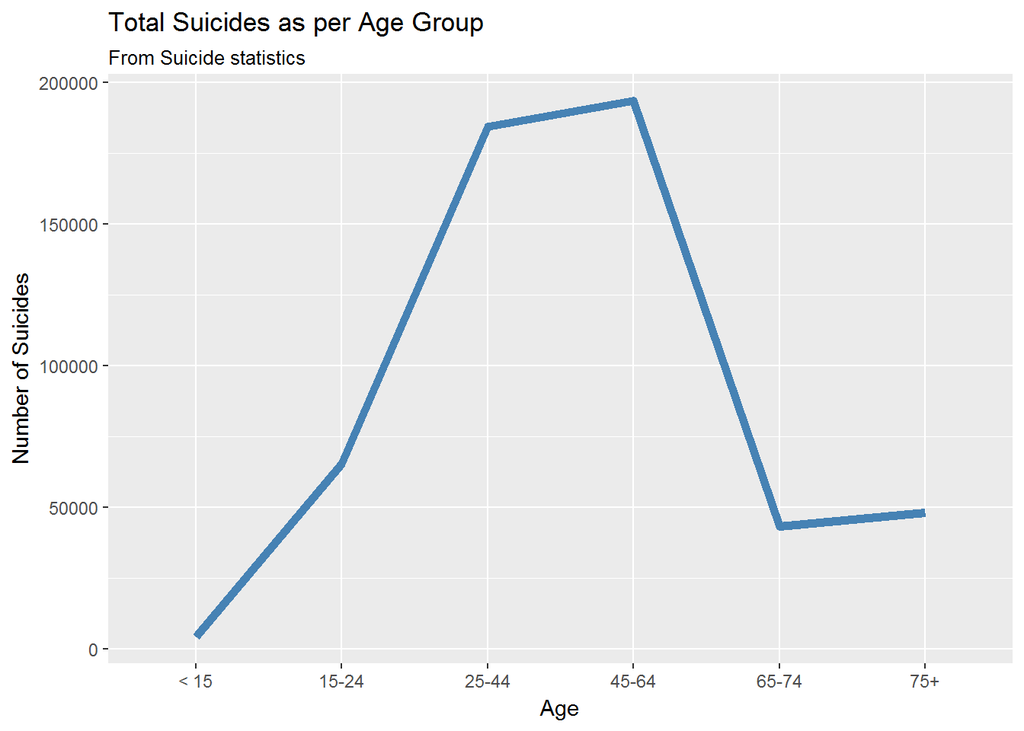

```r
ggplot(suicide.data.agewise, aes(x = as.factor(suicide.data.agewise$Age), y = suicide.data.agewise$totalSuicides,
    group = 1)) + geom_line(col = "steelblue", stat = "identity", size = 2) + labs(title = "Total Suicides as per Age Group",
    subtitle = "From Suicide statistics", y = "Number of Suicides", x = "Age") +
    scale_y_continuous(breaks = seq(0, 2e+05, 50000))
```

The above data shows that the middle age group of 45-64 have the highest rise in number of Suicides at 193509 and then age group 25-44 with a nearing figure of 184487. It can also be seen graphically that the age group has a great impact on overall Suicide rates. Age group 15-24 tend to have reasonably less number of Suicide rates.

### Suicide Rates by Year

Next, lets analyze correlation between Suicide rate and Year

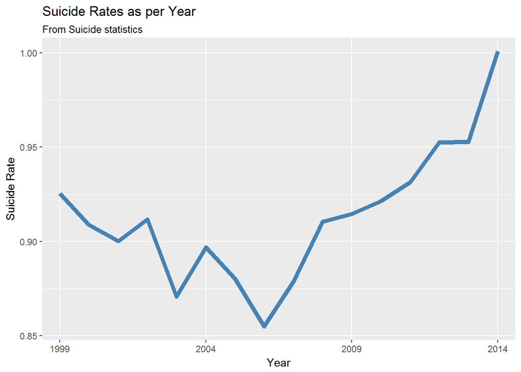

```r
suicide.data.yearwise = suicide.data %>% group_by(Year) %>% summarise(totalSuicides = mean(SuicidesPer100k)) %>%
    arrange(desc(totalSuicides))

ggplot(suicide.data.yearwise, aes(x = as.factor(suicide.data.yearwise$Year), y = suicide.data.yearwise$totalSuicides,
    group = 1)) + geom_line(col = "steelblue", stat = "identity", size = 2) + labs(title = "Suicide Rates as per Year",
    subtitle = "From Suicide statistics", y = "Suicide Rate", x = "Year") + scale_x_discrete(breaks = seq(1999,
    2014, 5))
```

It can be seen that the Suicide rate decreased moving from 1999 to 2006, had a increase around 2007, later became static and then increased moving towards year 2014. Highest Suicide rate was observed in 2014. So the Year factor has a high correlation with the Suicide Ratio.

Lets observe the impact of Age on the average suicide rate per year .

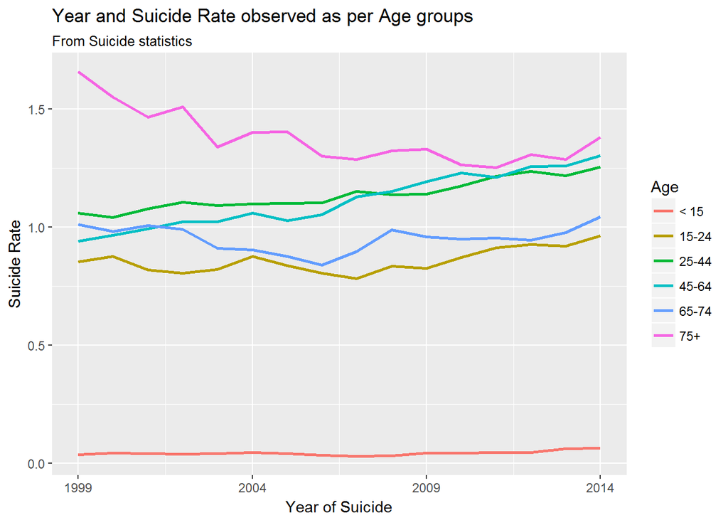

```r
avgsuiciderate.peragegroup.peryear = suicide.data %>% group_by_(.dots = c("Year",
    "Age")) %>% summarize(totalSuicides = mean(SuicidesPer100k))

ggplot(avgsuiciderate.peragegroup.peryear, aes(x = Year, y = totalSuicides)) + geom_line(aes(col = Age),
    size = 1) + labs(title = "Year and Suicide Rate observed as per Age groups",
    subtitle = "From Suicide statistics", y = "Suicide Rate", x = "Year of Suicide") +
    scale_x_continuous(breaks = seq(1999, 2014, 5))
```

# Suicide Rates by Sex of Person

Next, we analyze the impact of Gender on Suicide rates. We have Sex as a categorical variable having values Male and Female

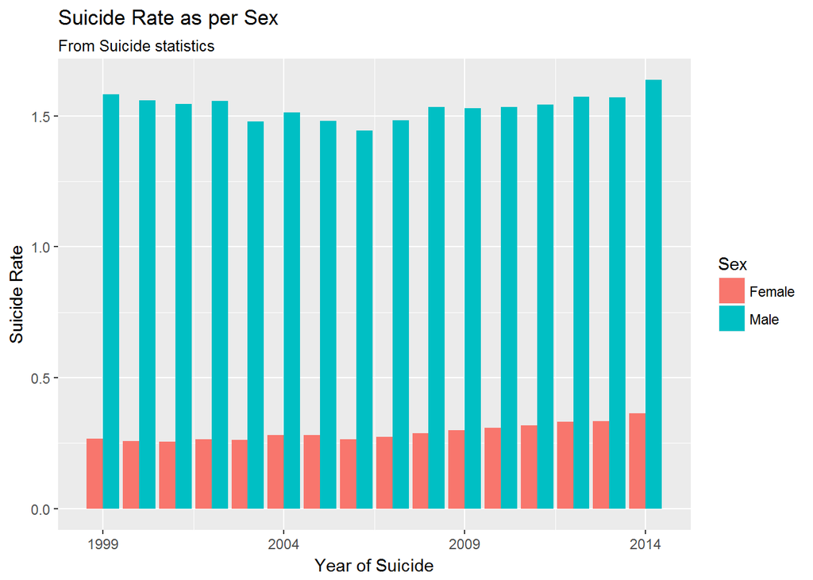

```r
suicide.data.bysex = suicide.data %>% group_by_(.dots = c("Year", "Sex")) %>% summarise(numberOfDeaths = mean(SuicidesPer100k)) %>%
    arrange(desc(numberOfDeaths))

ggplot(suicide.data.bysex, aes(x = Year, y = numberOfDeaths)) + geom_bar(aes(fill = Sex),
    position = "dodge", stat = "identity") + labs(title = "Suicide Rate as per Sex",
    subtitle = "From Suicide statistics", y = "Suicide Rate", x = "Year of Suicide") +
    scale_x_continuous(breaks = seq(1999, 2014, 5))
```

As can be seen above, the Sex of the person committing Suicide has great impact on the Number of Deaths. Male tend to suffer fatalities from suicides more than women. Trend can be observed across years 1999 to 2014.

# Suicide Rates by Race/Ethnicity

Next, we analyze effect on Race of a Person on Suicide Rates per Year. Race is a categorical variable having factors as Hispanic, Non-Hispanic Black and Non-Hispanic White.

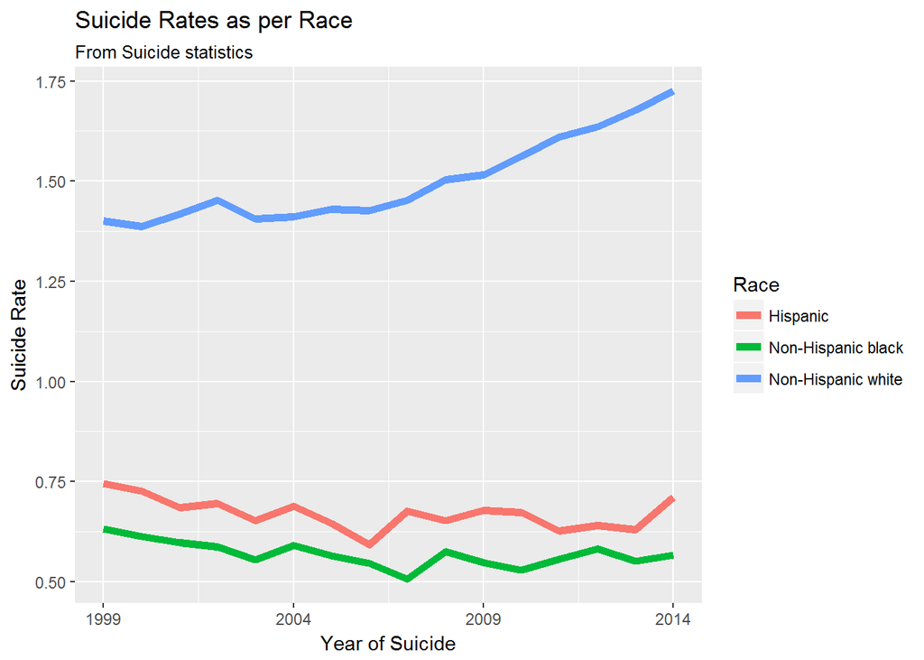

```r
avgsuiciderate.perracegrp.peryear = suicide.data %>% group_by_(.dots = c("Year",
    "Race")) %>% summarize(avgSuicides = mean(SuicidesPer100k))

ggplot(avgsuiciderate.perracegrp.peryear, aes(x = Year, y = avgSuicides)) + geom_line(aes(col = Race),
    size = 2) + labs(title = "Suicide Rates as per Race", subtitle = "From Suicide statistics",
    y = "Suicide Rate", x = "Year of Suicide") + scale_x_continuous(breaks = seq(1999,
    2014, 5))
```

Thus, Race of person committing suicide is also correlated to Suicide Rate.

# Suicide Rates by Injury Mechanism

Next, we analyse the correlation between Suicide rate and Injury Mechanism. Various injury mechanisms are used to commit suicide including Cut/pierce, Drowning, Fall, Fire/hot, Firearm etc. We analyze which injury mechanism is used most in committing Suicide.

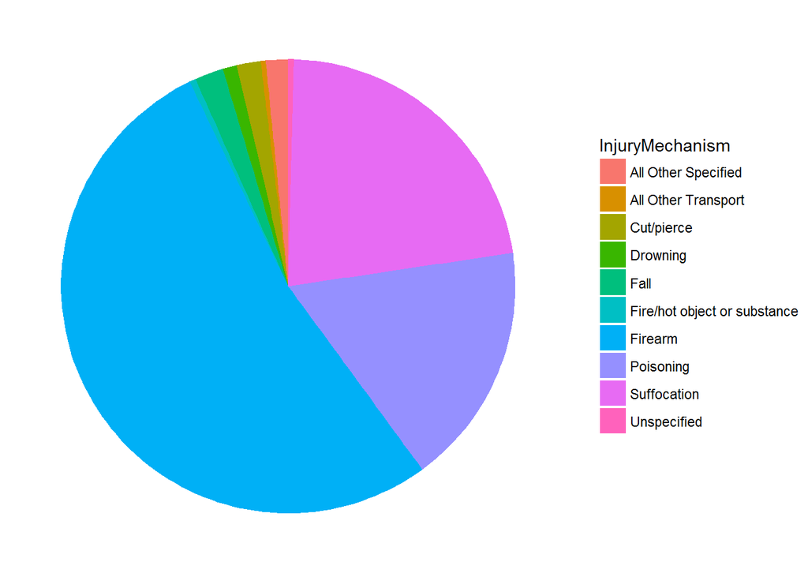

```r
suicide.injurymech.count = suicide.data %>% group_by(InjuryMechanism) %>% summarize(numberOfDeaths = sum(Deaths))
injurymech.barplot <- ggplot(suicide.injurymech.count, aes(x = "", y = numberOfDeaths,
    fill = InjuryMechanism)) + geom_bar(width = 1, stat = "identity")
pie.chart <- injurymech.barplot + coord_polar(theta = "y") + theme_void()
pie.chart
```

Now, analyzing effect of Sex of Person committing suicide to the mechanism used.

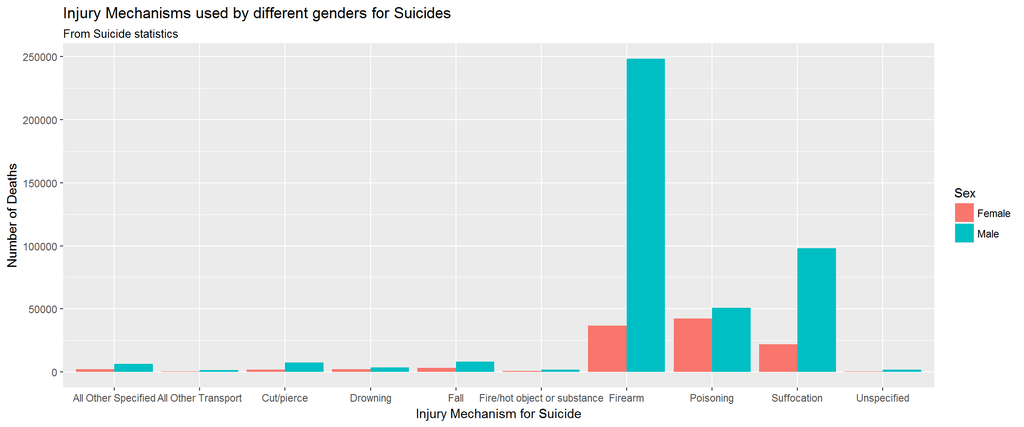

```r
suicide.data.injurymechanism = suicide.data %>% group_by_(.dots = c("InjuryMechanism",
    "Sex")) %>% summarise(numberOfDeaths = sum(Deaths)) %>% arrange(desc(numberOfDeaths))

ggplot(suicide.data.injurymechanism, aes(x = InjuryMechanism, y = numberOfDeaths)) +
    geom_bar(aes(fill = Sex), position = "dodge", stat = "identity") + labs(title = "Injury Mechanisms used by different genders for Suicides",
    subtitle = "From Suicide statistics", y = "Number of Deaths", x = "Injury Mechanism for Suicide") +
    scale_y_continuous(breaks = seq(0, 250000, 50000))
```

It can be observed that largest Suicide fatalities grouping for Men is using Firearms as the Injury mechanism, and for Women it is Poisoning. Thus the injury mechanisms are highly correlated to gender and Number of Deaths.

### Similar behavior can be observed when mapping Race against Injury mechanisms and Number of Deaths.

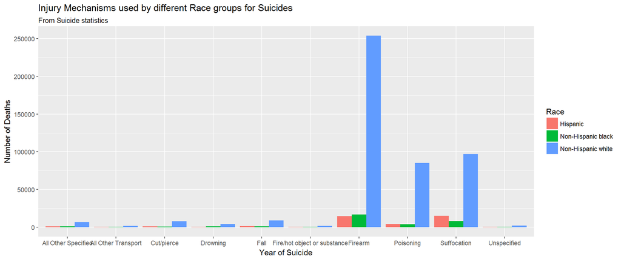

```r
suicide.data.byrace = suicide.data %>% group_by_(.dots = c("InjuryMechanism", "Race")) %>%
    summarise(numberOfDeaths = sum(Deaths)) %>% arrange(desc(numberOfDeaths))

ggplot(suicide.data.byrace, aes(x = InjuryMechanism, y = numberOfDeaths)) + geom_bar(aes(fill = Race),
    position = "dodge", stat = "identity") + labs(title = "Injury Mechanisms used by different Race groups for Suicides",
    subtitle = "From Suicide statistics", y = "Number of Deaths", x = "Year of Suicide") +
    scale_y_continuous(breaks = seq(0, 250000, 50000))
```

# In Conclusion:

Based on the data available, it would be in the interest of public health to investigate further the warning signs of suicide among older men with access to firearms. Many individuals at 75+ do not live independently, so perhaps educating their caretakers (nursing homes, their adult children) of warning signs and how to be supportive would help.

One particular pitfall for this data is that it only records fatalities, not attempts. Just because a suicide attempt does not result in a fatality does not mean it is not serious and should not be investigated. That data would be invaluable in continuing this study.